# Consumer Segmentation

# Project Overview

The goal of this project was to *identify* and *profile* distinct market segments within the consumer base of a travel technology company to inform personalized marketing and strategic audience engagement. As the company continues to expand its reach and tailor digital experiences for a diverse audience of travelers, understanding the different types of motivation and attitudes of users is critical.

The company currently serves travelers across various income levels and demographics. It offers a platform to assist with trip planning, itinerary curation, and travel budgeting. However, with increased competition in the travel tech space, the company’s market research team recognized the need for more granular segmentation based on psychographic features rather than just demographic indicators.

# Data Source

The data for this analysis was drawn from a survey of 502 U.S.-based adult leisure travelers. As part of a broader travel behavior study, respondents completed a 23-item scale designed to assess key dimensions of travel-related attitudes and behaviors. These items reflect well-established variables in travel research, including trip planning, sustainable travel preferences, cultural awareness, and budget consciousness (See Refs 1-7). Respondents rated each item using a 5-point Likert-type scale, ranging from “Not at all important” (1) to “Extremely important” (5). Demographic information such as gender and household income was also collected.

## Data Cleaning

To ensure data quality, responses were excluded based on predefined quality control criteria:

- *Attention Check Failures*: Respondents who did not pass embedded attention checks.
- *Speeders*: Respondents who completed the survey in an unrealistically short time.
- [*Straight-liners*](https://doi.org/10.1177/0894439317752406): Respondents who provided identical responses across all 23 survey items.

Following these exclusion criteria, the final analytic sample comprised 298 valid cases.

# Data Analysis

## Factor Analysis

The client provided a conceptual framework outlining four key dimensions of traveler motivations and attitudes. My role as a consultant was to explore whether these dimensions were supported by the data through an exploratory factor analysis (EFA).

The analysis ‘confirmed’ the presence of four factors:

- *Trip Readiness*: Represents the importance travelers place on being organized, informed, and prepared across key logistical and safety-related aspects of travel. It reflects pre-trip planning priorities and a traveler’s desire for control, clarity, and peace of mind throughout the travel experience.
- *Sustainable Travel*: Describes the value travelers assign to making environmentally responsible choices, particularly regarding accommodation and transportation. It indicates how much sustainability considerations influence their travel planning and decision-making.
- *Cultural Awareness*: Captures the degree to which travelers value cultural knowledge and immersion when preparing for a destination. It underscores the importance of understanding and appreciating the history, customs, and heritage of the places travelers visit.
- *Budget Consciousness*: Refers to the extent to which travelers value financial discipline and cost efficiency when making travel decisions. It emphasizes the importance of staying within budget, avoiding unnecessary expenses, and selecting low-cost options during trips.

Composite scores for each factor were computed and used as psychographic indicators in downstream cluster analysis.

## Model-based Clustering

This solution revealed a baseline segment(Spontaneous Explorers,22.6%) with low scores across most psychographic dimensions. In contrast, a second class(Intentional Explorers) consisting of 23.6% of participants exhibited high values in all dimensions reflecting a values-driven approach to travel. Interestingly, the largest segment (Practical Travelers, 53.8% )fell into a third class characterized by moderate budget consciousness suggesting a practical, efficiency-minded orientation.

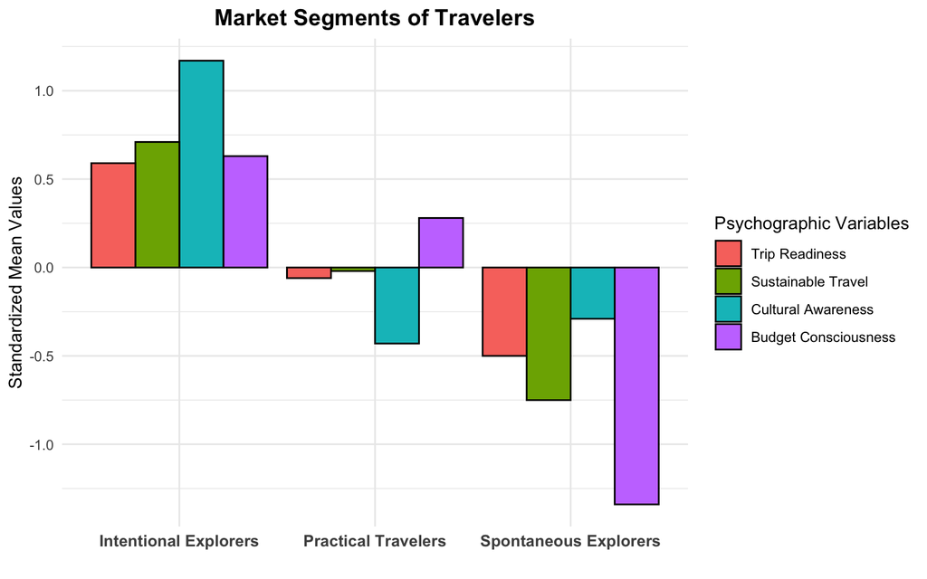

This analysis underscores the need for targeted strategies: while a meaningful portion of users seeks immersive, ethical experiences, the majority prioritize affordability and planning ease.

## Profiling

A multinomial logistic regression was conducted to evaluate whether demographic variables predicted segment membership. Based on the established significance threshold (p < .05), neither gender nor income emerged as a statistically significant predictor( See Table below). The finding suggests that traveler segmentation is more likely driven by mindset and behavioral priorities than by demographic characteristics alone. This underscores the value of a psychographic approach in understanding and engaging distinct traveler segments.

|  | Cluster Membership | Variable | Estimate | Std. Error | Statistic | P Value | Conf. Low | Conf. High |
| --- | --- | --- | --- | --- | --- | --- | --- | --- |
| 1 | Practical Travelers | Intercept | 1.359 | 0.367 | 3.704 | 0 | 0.64 | 2.078 |
| 2 | Practical Travelers | Male | 0.008 | 0.384 | 0.02 | 0.984 | -0.745 | 0.761 |
| 3 | Practical Travelers | Low Income | -0.83 | 0.424 | -1.958 | 0.05 | -1.66 | 0.001 |
| 4 | Practical Travelers | Middle Income | -0.508 | 0.426 | -1.193 | 0.233 | -1.342 | 0.327 |
| 5 | Spontaneous Explorers | Intercept | 0.072 | 0.442 | 0.164 | 0.87 | -0.794 | 0.939 |
| 6 | Spontaneous Explorers | Male | 0.616 | 0.429 | 1.434 | 0.152 | -0.226 | 1.457 |
| 7 | Spontaneous Explorers | Low Income | -0.713 | 0.519 | -1.373 | 0.17 | -1.73 | 0.304 |
| 8 | Spontaneous Explorers | Middle Income | -0.105 | 0.503 | -0.209 | 0.835 | -1.091 | 0.881 |

# Insights Summary

The segmentation analysis identified three distinct traveler segments. These segments represent meaningful differences in planning behavior, values, and travel priorities:

- **Intentional Explorers**: Highly engaged travelers who prioritize preparation, cultural immersion, eco-conscious choices, and financial discipline.
- **Practical Travelers**: Practical and cost-efficient travelers who focus on budgeting and essential planning. They are less motivated by cultural or sustainability concerns.
- **Spontaneous Explorers**: Low-engagement users with minimal interest in planning, budgeting, or values-based travel. They prefer simplicity and convenience, making them ideal candidates for pre-curated or perhaps automated travel solutions.

# Reccomendations

- Offer customizable planning tools and eco-cultural content for Intentional Explorers.
- Focus on budget features, deal-finders, and streamlined booking flows for Practical Travelers.
- Deliver AI-powered, low-effort itineraries for Spontaneous Explorers with minimal decision points.
- Use value-driven messaging for Intentional Explorers.
- Highlight simplicity and savings for Practical Travelers.
- Emphasize ease and spontaneity for Spontaneous Explorers.

# References

1. Falk, M., & Katz-Gerro, T. (2017). Modeling travel decisions: Urban exploration, cultural immersion, or both?. *Journal of Travel & Tourism Marketing*, 34(3), 369-382.
2. Gehlert, T., Dziekan, K., & Gärling, T. (2013). Psychology of sustainable travel behavior. *Transportation Research Part A: Policy and Practice*, 48, 19-24.
3. Pearce, P. L., & Lee, U.I. (2005). Developing the Travel Career Approach to Tourist Motivation. *Journal of Travel Research*, 43(3), 226-237. https://doi.org/10.1177/0047287504272020 (Original work published 2005)
4. Richards, G. (2002). Tourism attraction systems: Exploring cultural behavior. *Annals of Tourism Research*, 29(4), 1048-1064.
5. Shi, S., Gong, Y., & Gursoy, D. (2021). Antecedents of trust and adoption intention toward artificially intelligent recommendation systems in travel planning: a heuristic–systematic model. *Journal of Travel Research*, 60(8), 1714-1734.
6. Xiang, Z., Wang, D., O’Leary, J. T., & Fesenmaier, D. R. (2015). Adapting to the internet: trends in travelers’ use of the web for trip planning. *Journal of Travel Research*, 54(4), 511-527.
7. Xie, J., Zhang, K., Chen, J., Zhu, T., Lou, R., Tian, Y., … & Su, Y. (2024). Travelplanner: A benchmark for real-world planning with language agents. *arXiv preprint* arXiv:2402.01622.

Back to Top

[Back to Portfolio](https://wondimuahmed.github.io/Portfolio/)